# Untitled

David O’Dwyer

2023-11-03

#Set Up Genus Analysis

Pull clinical meta file

```r
meta<-read.csv("Umichgan_09.02.2022_postmatch.csv", header=T,row.names=1)
```

Pull shared file from Quitta

```r
data.trim<-read.csv("cleanup_q2silva_genusL6.counts_postmatch.csv", header=T,row.names=1)
data.trim<-as.matrix(data.trim)
```

Now to thresholds and remove OTUs below 0.1% of the population

```r
data.tmp<-decostand(data.trim,"total")*100
neg1<-which(data.tmp<0.1)
data.trim[neg1]<-0
pos<-which(colSums(data.trim)>0)
data.good<-data.trim[,pos]
dim(data.good)
```

```
## [1] 1203  423
```

```r
otu<-data.good
```

load taxonomy matching file

```r
data.taxonomy<-read.csv("cleanup_q2silva_genusL6.taxonomy.csv", header=T, row.names=1)
```

Check sets

```r
rownames(otu)==rownames(meta)
```

```
##    [1]  TRUE FALSE FALSE FALSE FALSE FALSE FALSE FALSE FALSE FALSE FALSE FALSE
##   [13] FALSE FALSE FALSE FALSE FALSE FALSE FALSE FALSE FALSE FALSE FALSE FALSE
##   [25] FALSE FALSE FALSE FALSE FALSE FALSE FALSE FALSE FALSE FALSE FALSE FALSE
##   [37] FALSE FALSE FALSE FALSE FALSE FALSE FALSE FALSE FALSE FALSE FALSE FALSE
##   [49] FALSE FALSE FALSE FALSE FALSE FALSE FALSE FALSE FALSE FALSE FALSE FALSE
##   [61] FALSE FALSE FALSE FALSE FALSE FALSE FALSE FALSE FALSE FALSE FALSE FALSE
##   [73] FALSE FALSE FALSE FALSE FALSE FALSE FALSE FALSE FALSE FALSE FALSE FALSE
##   [85] FALSE FALSE FALSE FALSE FALSE FALSE FALSE FALSE FALSE FALSE FALSE FALSE
##   [97] FALSE FALSE FALSE FALSE FALSE FALSE FALSE FALSE FALSE FALSE FALSE FALSE
##  [109] FALSE FALSE FALSE FALSE FALSE FALSE FALSE FALSE FALSE FALSE FALSE FALSE
##  [121] FALSE FALSE FALSE FALSE FALSE FALSE FALSE FALSE FALSE FALSE FALSE FALSE
##  [133] FALSE FALSE FALSE FALSE FALSE FALSE FALSE FALSE FALSE FALSE FALSE FALSE
##  [145] FALSE FALSE FALSE FALSE FALSE FALSE FALSE FALSE FALSE FALSE FALSE FALSE
##  [157] FALSE FALSE FALSE FALSE FALSE FALSE FALSE FALSE FALSE FALSE FALSE FALSE
##  [169] FALSE FALSE FALSE FALSE FALSE FALSE FALSE FALSE FALSE FALSE FALSE FALSE
```

[output cut: 86 more lines]

```r
dim(otu)
```

```
## [1] 1203  423
```

```r
dim(meta) #this is not matched for baseline
```

```
## [1] 511 455
```

Generate baseline dataset - .bas

```r
otu.bas.v<-grep("BAS", rownames(otu))
rownames(otu)[otu.bas.v]
```

[output not shown]

[output cut: 156 more lines]

```r
otu.bas.v<-otu[otu.bas.v,]
#dim(otu.bas.v)
#dim(otu)
```

Summing columns of zero

```r
pos.sel<-which(colSums(otu.bas.v)>0) # select out cols that sum to zero
otu.bas<-(otu.bas.v[,pos.sel]) #make this a component of otu, and then remove
#View(otu.bas.v)
#dim(otu.bas)
#dim(otu.bas.v)
```

Check sets

```r
rownames(otu.bas)==rownames(meta)
```

```
##   [1] TRUE TRUE TRUE TRUE TRUE TRUE TRUE TRUE TRUE TRUE TRUE TRUE TRUE TRUE TRUE
##  [16] TRUE TRUE TRUE TRUE TRUE TRUE TRUE TRUE TRUE TRUE TRUE TRUE TRUE TRUE TRUE
##  [31] TRUE TRUE TRUE TRUE TRUE TRUE TRUE TRUE TRUE TRUE TRUE TRUE TRUE TRUE TRUE
##  [46] TRUE TRUE TRUE TRUE TRUE TRUE TRUE TRUE TRUE TRUE TRUE TRUE TRUE TRUE TRUE
##  [61] TRUE TRUE TRUE TRUE TRUE TRUE TRUE TRUE TRUE TRUE TRUE TRUE TRUE TRUE TRUE
##  [76] TRUE TRUE TRUE TRUE TRUE TRUE TRUE TRUE TRUE TRUE TRUE TRUE TRUE TRUE TRUE
##  [91] TRUE TRUE TRUE TRUE TRUE TRUE TRUE TRUE TRUE TRUE TRUE TRUE TRUE TRUE TRUE
## [106] TRUE TRUE TRUE TRUE TRUE TRUE TRUE TRUE TRUE TRUE TRUE TRUE TRUE TRUE TRUE
## [121] TRUE TRUE TRUE TRUE TRUE TRUE TRUE TRUE TRUE TRUE TRUE TRUE TRUE TRUE TRUE
## [136] TRUE TRUE TRUE TRUE TRUE TRUE TRUE TRUE TRUE TRUE TRUE TRUE TRUE TRUE TRUE
## [151] TRUE TRUE TRUE TRUE TRUE TRUE TRUE TRUE TRUE TRUE TRUE TRUE TRUE TRUE TRUE
## [166] TRUE TRUE TRUE TRUE TRUE TRUE TRUE TRUE TRUE TRUE TRUE TRUE TRUE TRUE TRUE
## [181] TRUE TRUE TRUE TRUE TRUE TRUE TRUE TRUE TRUE TRUE TRUE TRUE TRUE TRUE TRUE
## [196] TRUE TRUE TRUE TRUE TRUE TRUE TRUE TRUE TRUE TRUE TRUE TRUE TRUE TRUE TRUE
## [211] TRUE TRUE TRUE TRUE TRUE TRUE TRUE TRUE TRUE TRUE TRUE TRUE TRUE TRUE TRUE
```

[output cut: 20 more lines]

```r
dim(otu)
```

```
## [1] 1203  423
```

```r
dim(meta)
```

```
## [1] 511 455
```

```r
dim(otu.bas)
```

```
## [1] 511 237
```

#Rank abundace all

```r
otu.bas.norm<-decostand(otu.bas, "total")*100
#write.csv(otu.bas.norm, "rank.abund.basline.all.csv")
```

#Principal component analysis Initial set up Build PCA from hellinger transformed data

```r
otu.bas.hell<-decostand(otu.bas, "hellinger")
otu.bas.pca<-rda(otu.bas.hell)
plot(otu.bas.pca)
```

[output not shown]

```r
head(summary(otu.bas.pca)) #Proportion Explained  PC1 0.25445 PC2 0.1861
```

```
##
## Call:
## rda(X = otu.bas.hell)
##
## Partitioning of variance:
##               Inertia Proportion
## Total          0.2439          1
## Unconstrained  0.2439          1
##
## Eigenvalues, and their contribution to the variance
##
## Importance of components:
##                           PC1    PC2     PC3     PC4     PC5     PC6      PC7
## Eigenvalue            0.06206 0.0454 0.02261 0.01688 0.01340 0.01068 0.008561
## Proportion Explained  0.25445 0.1861 0.09272 0.06922 0.05492 0.04379 0.035100
## Cumulative Proportion 0.25445 0.4406 0.53328 0.60249 0.65741 0.70120 0.736298
##                            PC8      PC9     PC10     PC11     PC12     PC13
## Eigenvalue            0.007954 0.006341 0.005041 0.004218 0.003911 0.003271
## Proportion Explained  0.032611 0.025999 0.020668 0.017294 0.016033 0.013412
## Cumulative Proportion 0.768909 0.794908 0.815576 0.832870 0.848903 0.862315
##                           PC14     PC15     PC16     PC17     PC18     PC19
## Eigenvalue            0.003041 0.002581 0.002356 0.002035 0.001820 0.001655
## Proportion Explained  0.012466 0.010582 0.009660 0.008341 0.007462 0.006785
## Cumulative Proportion 0.874781 0.885363 0.895023 0.903364 0.910826 0.917612
##                           PC20     PC21     PC22     PC23     PC24      PC25
## Eigenvalue            0.001579 0.001407 0.001174 0.001145 0.000999 0.0009059
## Proportion Explained  0.006475 0.005768 0.004812 0.004695 0.004096 0.0037143
## Cumulative Proportion 0.924086 0.929854 0.934666 0.939361 0.943457 0.9471713
##                            PC26      PC27      PC28      PC29     PC30     PC31
## Eigenvalue            0.0008387 0.0007679 0.0007429 0.0006307 0.000613 0.000544
## Proportion Explained  0.0034388 0.0031484 0.0030457 0.0025859 0.002513 0.002230
## Cumulative Proportion 0.9506101 0.9537584 0.9568041 0.9593900 0.961903 0.964134
##                            PC32      PC33      PC34      PC35      PC36
## Eigenvalue            0.0004875 0.0004752 0.0004381 0.0004104 0.0003696
## Proportion Explained  0.0019987 0.0019484 0.0017960 0.0016825 0.0015154
## Cumulative Proportion 0.9661325 0.9680809 0.9698769 0.9715594 0.9730748
##                            PC37      PC38      PC39      PC40      PC41
## Eigenvalue            0.0003602 0.0003272 0.0002974 0.0002915 0.0002605
## Proportion Explained  0.0014768 0.0013417 0.0012194 0.0011949 0.0010680
## Cumulative Proportion 0.9745515 0.9758932 0.9771126 0.9783076 0.9793756
```

[output cut: 130 more lines]

```
## g005 -0.1849  0.17573  0.09256 -0.64278  0.39901 0.1846
## g006  0.5146 -0.16278 -0.41357 -0.06009 -0.05053 0.1291
## ....
##
##
## Site scores (weighted sums of species scores)
##
##                          PC1       PC2       PC3      PC4       PC5      PC6
## 13516.113A.0001.BAS -0.17550 -0.083807 -0.063050 -0.09199  0.049518  0.06756
## 13516.113A.0002.BAS  0.06620 -0.210928 -0.003847  0.20802  0.089089  0.13272
## 13516.113A.0003.BAS -0.22962  0.007198 -0.096197  0.02229 -0.088291 -0.03623
## 13516.113A.0004.BAS -0.06630  0.145247  0.028473  0.16056 -0.039098  0.02848
## 13516.113A.0005.BAS -0.05445  0.105418  0.100068  0.01040 -0.140735 -0.08276
## 13516.113A.0006.BAS -0.21130  0.033098 -0.027349  0.07224 -0.008382  0.02085
## ....
```

Basic PCA ordination

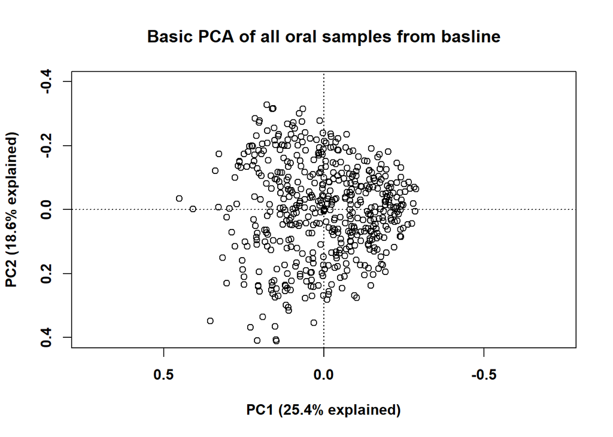

```r
par(mfrow=c(1,1))

plot(otu.bas.pca,type="n",font=2,font.lab=2,xlim=c(0.4, -0.4), ylim=c(0.4, -0.4), xlab="PC1 (25.4% explained)",
     ylab="PC2 (18.6% explained)",main="Basic PCA of all oral samples from basline") # plotting the space
points(otu.bas.pca,pch=21,cex=1.0)
```

#Study site Variation in Beta diversity by study site

```r
site1<-grep("113", meta$sitenum)
site2<-grep("121", meta$sitenum)
site3<-grep("136",meta$sitenum)
site4<-grep("155", meta$sitenum)
site5<-grep("156", meta$sitenum)
site6<-grep("158", meta$sitenum)
site7<-grep("159", meta$sitenum)
site8<-grep("161", meta$sitenum)
site9<-grep("162", meta$sitenum)
site10<-grep("163", meta$sitenum)
site11<-grep("164", meta$sitenum)
site12<-grep("165", meta$sitenum)
site13<-grep("167", meta$sitenum)
site14<-grep("169", meta$sitenum)
site15<-grep("170", meta$sitenum)
site16<-grep("172", meta$sitenum)
site17<-grep("173", meta$sitenum)
site18<-grep("176", meta$sitenum)
site19<-grep("180", meta$sitenum)
site20<-grep("188", meta$sitenum)
site21<-grep("189", meta$sitenum)
site22<-grep("194", meta$sitenum)
site23<-grep("196", meta$sitenum)
site24<-grep("204", meta$sitenum)
site25<-grep("205", meta$sitenum)
site26<-grep("206", meta$sitenum)
site27<-grep("208", meta$sitenum)
site28<-grep("210", meta$sitenum)
site29<-grep("211", meta$sitenum)
site30<-grep("213", meta$sitenum)
site31<-grep("215", meta$sitenum)
site32<-grep("223", meta$sitenum)
site33<-grep("224", meta$sitenum)
site34<-grep("231", meta$sitenum)
site35<-grep("232", meta$sitenum)
```

```r
samples.site<-as.character()
samples.site[site1]<-"site 1"
samples.site[site2]<-"site 2"
samples.site[site3]<-"site 3"
samples.site[site4]<-"site 4"
samples.site[site5]<-"site 5"
samples.site[site6]<-"site 6"
samples.site[site7]<-"site 7"
samples.site[site8]<-"site 8"
samples.site[site9]<-"site 9"
samples.site[site10]<-"site 10"
samples.site[site11]<-"site 11"
samples.site[site12]<-"site 12"
samples.site[site13]<-"site 13"
samples.site[site14]<-"site 14"
samples.site[site15]<-"site 15"
samples.site[site16]<-"site 16"
samples.site[site17]<-"site 17"
samples.site[site18]<-"site 18"
samples.site[site19]<-"site 19"
samples.site[site20]<-"site 20"
samples.site[site21]<-"site 21"
samples.site[site22]<-"site 22"
samples.site[site23]<-"site 23"
samples.site[site24]<-"site 24"
samples.site[site25]<-"site 25"
samples.site[site26]<-"site 26"
samples.site[site27]<-"site 27"
samples.site[site28]<-"site 28"
samples.site[site29]<-"site 29"
samples.site[site30]<-"site 30"
samples.site[site31]<-"site 31"
samples.site[site32]<-"site 32"
samples.site[site33]<-"site 33"
samples.site[site34]<-"site 34"
samples.site[site35]<-"site 35"
samples.site<-as.factor(samples.site)
#samples.site
```

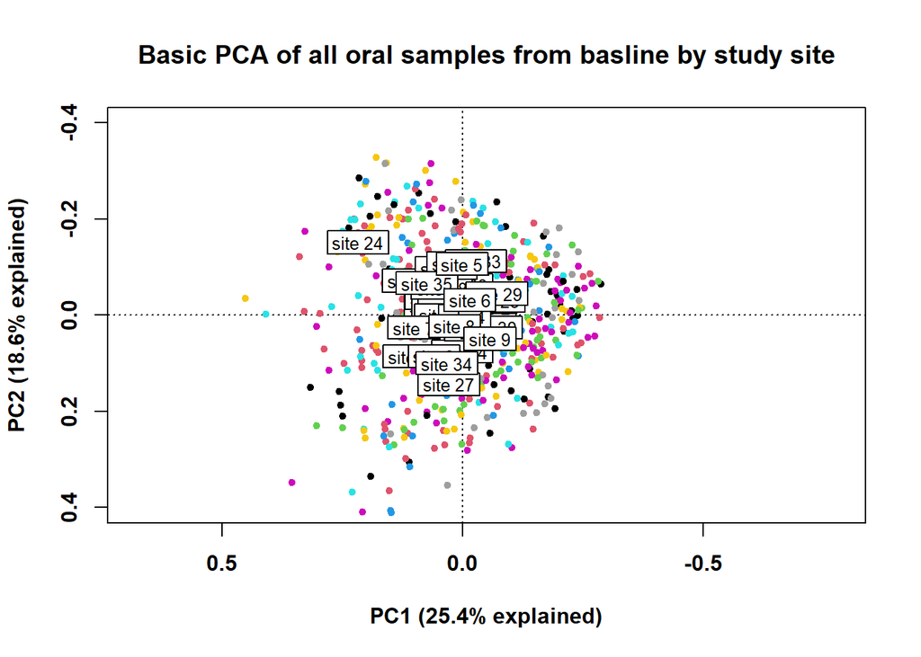

```r
par(mfrow=c(1,1))

plot(otu.bas.pca,type="n",font=2,font.lab=2,xlim=c(0.3, -0.4), ylim=c(0.4, -0.4),xlab="PC1 (25.4% explained)",
     ylab="PC2 (18.6% explained)",main="Basic PCA of all oral samples from basline by study site") # plotting the space
points(otu.bas.pca,pch=20,col=as.numeric(samples.site),cex=1.0) #plotting the datapoints
ordispider(otu.bas.pca, samples.site,label=T,lty=0) #generating the spiders and centroids
```

```r
set.seed(241279)
adonis(otu.bas.hell~samples.site, method="euclidean", permutations=10000) #p=0.0013
```

```
##
## Call:
## adonis(formula = otu.bas.hell ~ samples.site, permutations = 10000,      method = "euclidean")
##
## Permutation: free
## Number of permutations: 10000
##
## Terms added sequentially (first to last)
##
##               Df SumsOfSqs MeanSqs F.Model      R2 Pr(>F)
## samples.site  34    10.708 0.31493  1.3186 0.08608 0.0013 **
## Residuals    476   113.685 0.23883         0.91392
## Total        510   124.393                 1.00000
## ---
## Signif. codes:  0 '***' 0.001 '**' 0.01 '*' 0.05 '.' 0.1 ' ' 1
```

Variation with study site

#Biological Sex Beta diversity

```r
table(meta$SEX)
```

```
##
##   1   2
## 400 111
```

```r
male<-grep("1", meta$SEX)       #check male =1 , female=2
female<-grep("2", meta$SEX)

samples.sex<-as.character()
samples.sex[male]<-"male"
samples.sex[female]<-"female"
samples.sex<-as.factor(samples.sex)
#samples.sex
```

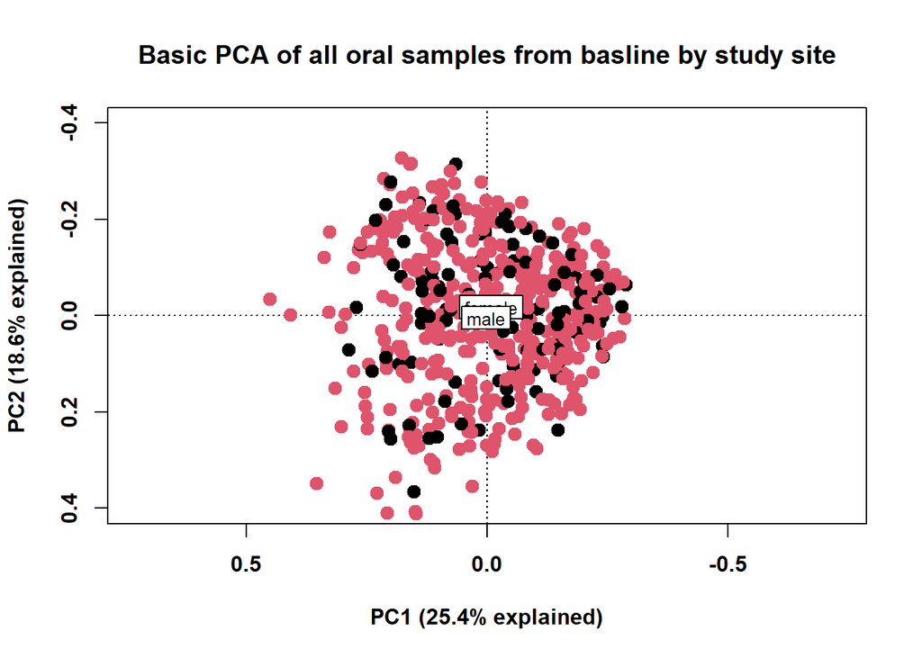

```r
par(mfrow=c(1,1))

plot(otu.bas.pca,type="n",font=2,font.lab=2,xlim=c(0.4, -0.4), ylim=c(0.4, -0.4),xlab="PC1 (25.4% explained)",
     ylab="PC2 (18.6% explained)",main="Basic PCA of all oral samples from basline by study site") # plotting the space
points(otu.bas.pca,pch=20,col=as.numeric(samples.sex),cex=2.0) #plotting the datapoints
ordispider(otu.bas.pca, samples.sex,label=T,lty=0) #generating the spiders and centroids
```

```r
set.seed(2412)
adonis(otu.bas.hell~samples.sex, method="euclidean", permutations=10000)  #p=0.31
```

```
##
## Call:
## adonis(formula = otu.bas.hell ~ samples.sex, permutations = 10000,      method = "euclidean")
##
## Permutation: free
## Number of permutations: 10000
##
## Terms added sequentially (first to last)
##
##              Df SumsOfSqs MeanSqs F.Model      R2 Pr(>F)
## samples.sex   1     0.271 0.27104  1.1115 0.00218 0.3141
## Residuals   509   124.122 0.24385         0.99782
## Total       510   124.393                 1.00000
```

Alpha diversity by sex

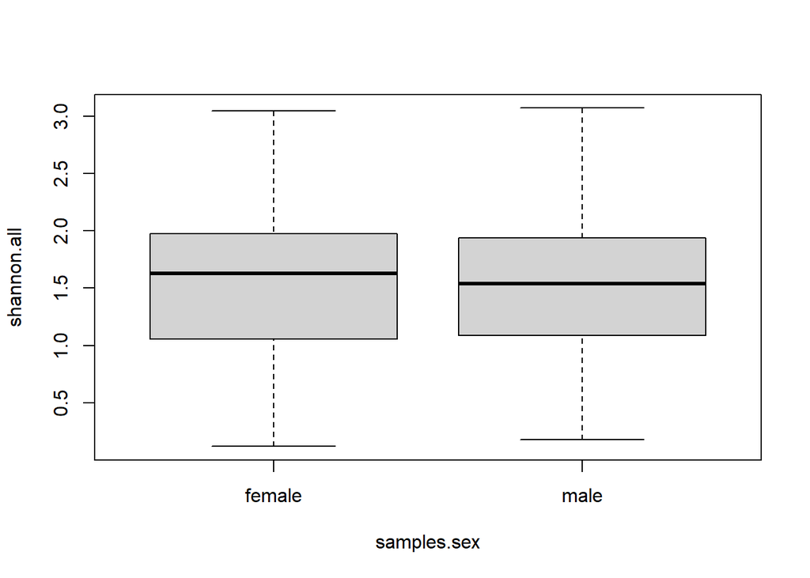

```r
shannon.all<-diversity(otu.bas, "shannon")
boxplot(shannon.all~samples.sex)
```

```r
data.shan.sex<-cbind(shannon.all, meta$SEX)   #bind data by column
data.shan.sex<-as.data.frame(data.shan.sex)      #generate data frame
colnames(data.shan.sex)[2]="sex"  #rename col 2 in data as sex
colnames(data.shan.sex)
```

```
## [1] "shannon.all" "sex"
```

```r
data.shan.sex$sex<-as.factor(data.shan.sex$sex)
```

```r
table(data.shan.sex)
```

[output not shown]

[output cut: 458 more lines]

[output not shown]

```r
summary(data.shan.sex)
```

```
##   shannon.all     sex
##  Min.   :0.1192   1:400
##  1st Qu.:1.0897   2:111
##  Median :1.5459
##  Mean   :1.5256
##  3rd Qu.:1.9444
##  Max.   :3.0719
```

```r
data.shan.sex %>%
  group_by(sex) %>%
  summarize(mean=mean(shannon.all), sd=sd(shannon.all))
```

```
## # A tibble: 2 x 3
##   sex    mean    sd
##   <fct> <dbl> <dbl>
## 1 1      1.52 0.574
## 2 2      1.55 0.639
```